# Tugas Individu 3 - Regresi dengan Peubah Lag

Nesa Saidah Meilani Putri - M0401241021

# 1. Persiapan Data

## *Packages*

```r
 # install.packages(c("dLagM", "dynlm", "MLmetrics", "lmtest", "car"))
```

```r
library(dLagM)
library(dynlm)
library(MLmetrics)
library(lmtest)
library(car)
```

## 1.1 Impor Data

```r
library(readxl)
library(dplyr)
data <- read.csv("C:/Users/Nesa/OneDrive/Semester 5/Metode Peramalan Deret Waktu/Praktikum/Praktikum 3/NewDelhi_Air_quality.csv")
head(data)
```

```
##   X  AQI       CO      datetime        NO2       O3      PM10    PM2.5
## 1 0 30.2 198.6027 2022-10-21:18 0.04685717 55.78995 10.486722 5.637410
## 2 1 28.2 197.6013 2022-10-21:19 0.04645554 54.93164 10.719325 4.618169
## 3 2 26.6 198.6027 2022-10-21:20 0.04685717 54.64554 11.155578 3.520902
## 4 3 25.0 201.9405 2022-10-21:21 0.04819594 55.07469 11.116206 2.225919
## 5 4 26.0 205.2784 2022-10-21:22 0.04886533 55.78995 10.405250 1.979471
## 6 5 26.0 208.6163 2022-10-21:23 0.05020411 56.50520  9.402518 1.792677
##         SO2     timestamp_local       timestamp_utc         ts
## 1 0.3874302 2022-10-21T23:00:00 2022-10-21T18:00:00 1666375200
## 2 0.4097819 2022-10-22T00:00:00 2022-10-21T19:00:00 1666378800
## 3 0.4023313 2022-10-22T01:00:00 2022-10-21T20:00:00 1666382400
## 4 0.3762543 2022-10-22T02:00:00 2022-10-21T21:00:00 1666386000
## 5 0.3390014 2022-10-22T03:00:00 2022-10-21T22:00:00 1666389600
## 6 0.3129244 2022-10-22T04:00:00 2022-10-21T23:00:00 1666393200
```

```r
str(data)
```

```
## 'data.frame':    72 obs. of  12 variables:
##  $ X              : int  0 1 2 3 4 5 6 7 8 9 ...
##  $ AQI            : num  30.2 28.2 26.6 25 26 26 26 24 23 24 ...
##  $ CO             : num  199 198 199 202 205 ...
##  $ datetime       : chr  "2022-10-21:18" "2022-10-21:19" "2022-10-21:20" "2022-10-21:21" ...
##  $ NO2            : num  0.0469 0.0465 0.0469 0.0482 0.0489 ...
##  $ O3             : num  55.8 54.9 54.6 55.1 55.8 ...
##  $ PM10           : num  10.5 10.7 11.2 11.1 10.4 ...
##  $ PM2.5          : num  5.64 4.62 3.52 2.23 1.98 ...
##  $ SO2            : num  0.387 0.41 0.402 0.376 0.339 ...
##  $ timestamp_local: chr  "2022-10-21T23:00:00" "2022-10-22T00:00:00" "2022-10-22T01:00:00" "2022-10-22T02:00:00" ...
##  $ timestamp_utc  : chr  "2022-10-21T18:00:00" "2022-10-21T19:00:00" "2022-10-21T20:00:00" "2022-10-21T21:00:00" ...
##  $ ts             : int  1666375200 1666378800 1666382400 1666386000 1666389600 1666393200 1666396800 1666400400 1666404000 1666407600 ...
```

## 1.2 Menetapkan Variabel

AQI ditetapkan sebagai variabel dependen (Y) dan salah satu polutan sebagai variabel independen (X).

```r
Y <- data$AQI
X <- data$O3

data <- data.frame(
  AQI = data$AQI,
  O3 = data$O3
)
```

```r
head(data)
```

```
##    AQI       O3
## 1 30.2 55.78995
## 2 28.2 54.93164
## 3 26.6 54.64554
## 4 25.0 55.07469
## 5 26.0 55.78995
## 6 26.0 56.50520
```

**Interpretasi:** Pada analisis ini, AQI digunakan sebagai variabel dependen (Y), sedangkan O3 digunakan sebagai variabel independen (X).

## 1.3 Pembagian *(Split)* Data

```r
# Membagi data (58 observasi pertama untuk training, 14 observasi terakhir untuk testing)
train <- data[1:58, ]
test <- data[59:72, ]

# Mengubah data menjadi objek time series
train.ts <- ts(train)
test.ts <- ts(test)
data.ts <- ts(data)
```

**Interpretasi:** Data dibagi menjadi 58 observasi pertama sebagai data training untuk membentuk model dan 14 observasi terakhir sebagai data testing untuk mengevaluasi hasil peramalan.

# 2. Model Koyck

## 2.1 Pemodelan

```r
# Membangun Model Koyck
model.koyck <- koyckDlm(
  x = train$O3,
  y = train$AQI
)

summary(model.koyck)
```

```
##
## Call:
## "Y ~ (Intercept) + Y.1 + X.t"
##
## Residuals:
##       Min        1Q    Median        3Q       Max
## -1.112282 -0.366467 -0.002877  0.258311  1.106529
##
## Coefficients:
##             Estimate Std. Error t value Pr(>|t|)
## (Intercept)  0.26260    0.93950   0.280    0.781
## Y.1          0.42943    0.08641   4.969 7.14e-06 ***
## X.t          0.25823    0.04259   6.064 1.35e-07 ***
## ---
## Signif. codes:  0 '***' 0.001 '**' 0.01 '*' 0.05 '.' 0.1 ' ' 1
##
## Residual standard error: 0.5239 on 54 degrees of freedom
## Multiple R-Squared: 0.9449,  Adjusted R-squared: 0.9429
## Wald test: 417.1 on 2 and 54 DF,  p-value: < 2.2e-16
##
## Diagnostic tests:
## NULL
##
##                             alpha      beta       phi
## Geometric coefficients:  0.460243 0.2582336 0.4294305
```

**Interpretasi:** Berdasarkan hasil pemodelan Koyck, peubah $X_t$ dan $Y_{t-1}$ memiliki *P-value* kurang dari 0.05, sehingga keduanya berpengaruh signifikan terhadap $Y_t$. Koefisien $X_t$ sebesar 0.25823 menunjukkan bahwa kenaikan O3 pada periode saat ini cenderung meningkatkan AQI pada periode saat ini. Sementara itu, koefisien $Y_{t-1}$ sebesar 0.42943 menunjukkan adanya pengaruh nilai AQI pada periode sebelumnya terhadap AQI saat ini.

Nilai $R^2$ sebesar 0.9449 menunjukkan bahwa sekitar 94.49% keragaman AQI dapat dijelaskan oleh model Koyck, sedangkan sisanya dijelaskan oleh faktor lain di luar model.

Persamaan model Koyck yang diperoleh adalah:

$$\hat{Y_t}=0.26260+0.25823X_t+0.42943Y_{t-1}$$

## 2.2 Peramalan

```r
# Meramalkan 14 periode ke depan
fore.koyck <- forecast(
  model = model.koyck,
  x = test$O3,
  h = 14
)

fore.koyck
```

```
## $forecasts
##  [1] 22.51461 21.65971 20.92318 20.05278 19.58666 19.84824 20.51469 20.80088
##  [9] 20.92378 21.43831 22.95219 24.71052 26.20441 27.21533
##
## $call
## forecast.koyckDlm(model = model.koyck, x = test$O3, h = 14)
##
## attr(,"class")
## [1] "forecast.koyckDlm" "dLagM"
```

```r
# Cek Akuras (MAPE) pada data testing
mape.koyck <- MAPE(
  fore.koyck$forecasts,
  test$AQI
)

cat("MAPE Model Koyck:", mape.koyck, "\n")
```

```
## MAPE Model Koyck: 0.02909543
```

**Interpretasi:** Model Koyck digunakan untuk meramalkan AQI sebanyak 14 periode pada data testing. Hasil evaluasi menghasilkan nilai MAPE sebesar 0.02909543 atau sekitar **2.91%**. Nilai tersebut nantinya digunakan untuk membandingkan tingkat akurasi model Koyck dengan model DLM dan ARDL.

# 3. *Regression with Distributed Lag (DLM)*

## 3.1 Pemodelan *(Lag = 2)*

Parameter `q = 2` berarti kita memasukkan $X_t, X_{t-1}$, dan $X_{t-2}$.

```r
model.dlm <- dlm(
  x = train$O3,
  y = train$AQI,
  q = 2
)

summary(model.dlm)
```

```
##
## Call:
## lm(formula = model.formula, data = design)
##
## Residuals:
##      Min       1Q   Median       3Q      Max
## -0.48041 -0.34171 -0.01844  0.25829  1.41892
##
## Coefficients:
##              Estimate Std. Error t value Pr(>|t|)
## (Intercept) -0.170522   0.676995  -0.252    0.802
## x.t          0.487583   0.052341   9.315 1.13e-12 ***
## x.1         -0.017540   0.098118  -0.179    0.859
## x.2         -0.005899   0.055262  -0.107    0.915
## ---
## Signif. codes:  0 '***' 0.001 '**' 0.01 '*' 0.05 '.' 0.1 ' ' 1
##
## Residual standard error: 0.3496 on 52 degrees of freedom
## Multiple R-squared:  0.9763, Adjusted R-squared:  0.9749
## F-statistic: 713.6 on 3 and 52 DF,  p-value: < 2.2e-16
##
## AIC and BIC values for the model:
##        AIC     BIC
## 1 47.04815 57.1749
```

**Interpretasi:** Pada model DLM dengan lag 2, peubah O3 pada periode saat ini ($X_t$) berpengaruh signifikan terhadap AQI karena memiliki *P-value* kurang dari 0.05. Sementara itu, O3 pada lag 1 dan lag 2 tidak menunjukkan pengaruh yang signifikan terhadap AQI. Model ini memiliki nilai $R^2$ sebesar 0.9763.

## 3.2 Penentuan *Lag* Optimum

```r
dlm.opt <- finiteDLMauto(
  formula = AQI ~ O3,
  data = train,
  q.min = 1,
  q.max = 10,
  model.type = "dlm",
  error.type = "AIC",
  trace = TRUE
)
```

[output not shown]

```r
# Membangun ulang DLM dengan Lag Optimum (q=10)
model.dlm.opt <- dlm(
  x = train$O3,
  y = train$AQI,
  q = 10
)

summary(model.dlm.opt)
```

```
##
## Call:
## lm(formula = model.formula, data = design)
##
## Residuals:
##      Min       1Q   Median       3Q      Max
## -0.48304 -0.17355  0.04636  0.17934  0.52554
##
## Coefficients:
##             Estimate Std. Error t value Pr(>|t|)
## (Intercept) -0.64267    0.89957  -0.714  0.47958
## x.t          0.42814    0.06180   6.928 4.08e-08 ***
## x.1          0.13889    0.13339   1.041  0.30473
## x.2         -0.05734    0.12788  -0.448  0.65654
## x.3         -0.14994    0.12237  -1.225  0.22840
## x.4          0.15911    0.12493   1.274  0.21095
## x.5         -0.01335    0.12436  -0.107  0.91510
## x.6         -0.12709    0.12430  -1.022  0.31338
## x.7          0.27371    0.12253   2.234  0.03180 *
## x.8         -0.37459    0.12097  -3.097  0.00378 **
## x.9          0.28924    0.10409   2.779  0.00862 **
## x.10        -0.09537    0.04837  -1.971  0.05640 .
## ---
## Signif. codes:  0 '***' 0.001 '**' 0.01 '*' 0.05 '.' 0.1 ' ' 1
##
## Residual standard error: 0.2739 on 36 degrees of freedom
## Multiple R-squared:  0.9877, Adjusted R-squared:  0.9839
## F-statistic: 262.6 on 11 and 36 DF,  p-value: < 2.2e-16
##
## AIC and BIC values for the model:
##        AIC      BIC
## 1 24.10757 48.43318
```

**Interpretasi:** Berdasarkan model DLM dengan lag optimum $q=10$, O3 pada periode saat ini memiliki pengaruh yang signifikan terhadap AQI. Beberapa peubah lag O3 juga menunjukkan pengaruh yang signifikan, yaitu lag 7, lag 8, dan lag 9. Sementara itu, lag lainnya tidak signifikan pada taraf 5%.

Nilai $R^2$ sebesar 0.9877 menunjukkan bahwa sekitar 98.77% keragaman AQI dapat dijelaskan oleh model DLM. Nilai AIC yang diperoleh sebesar 24.10757 digunakan sebagai salah satu ukuran dalam pemilihan model.

```r
# Peramalan DLM optimum
fore.dlm.opt <- forecast(
  model = model.dlm.opt,
  x = test$O3,
  h = 14
)

fore.dlm.opt
```

```
## $forecasts
##  [1] 21.71254 20.68921 20.02702 19.13710 18.76899 19.53092 20.95694 21.06735
##  [9] 20.45470 21.52028 23.77255 26.47778 27.61003 27.92625
##
## $call
## forecast.dlm(model = model.dlm.opt, x = test$O3, h = 14)
##
## attr(,"class")
## [1] "forecast.dlm" "dLagM"
```

```r
# Menghitung MAPE DLM
mape.dlm.opt <- MAPE(
  fore.dlm.opt$forecasts,
  test$AQI
)

cat("MAPE Model DLM Optimum:", mape.dlm.opt, "\n")
```

```
## MAPE Model DLM Optimum: 0.0127254
```

**Interpretasi:** Model DLM dengan lag optimum $q=10$ digunakan untuk meramalkan AQI sebanyak 14 periode pada data testing. Hasil evaluasi menunjukkan nilai MAPE sebesar 0.0127254 atau sekitar **1.27%**. Nilai MAPE ini akan dibandingkan dengan model Koyck dan ARDL untuk menentukan model dengan hasil peramalan terbaik.

# 4. *Autoregressive Distributed Lag (ARDL)*

ARDL menggabungkan: 1. $X_t$ 2. lag $X$ 3. lag $Y$

**Perhatian Notasi:**

Pada *package* `dLagM` (khusus fungsi `ardlDlm`), aturannya adalah:

- $p$ = panjang *lag* peubah independen ($X$).
- $q$ = panjang *lag* peubah dependen ($Y$).

## 4.1 Pemodelan

ARDL ($p$,$q$) = (1,1)

```r
# Model ARDL dengan lag X = 1 dan lag Y = 1
model.ardl <- ardlDlm(
  formula = AQI ~ O3,
  data = train,
  p = 1,
  q = 1
)

summary(model.ardl)
```

```
##
## Time series regression with "ts" data:
## Start = 2, End = 58
##
## Call:
## dynlm(formula = as.formula(model.text), data = data)
##
## Residuals:
##     Min      1Q  Median      3Q     Max
## -1.0233 -0.2713  0.1217  0.2984  0.8689
##
## Coefficients:
##             Estimate Std. Error t value Pr(>|t|)
## (Intercept) -0.24530    0.66489  -0.369    0.714
## O3.t         0.48660    0.03236  15.036  < 2e-16 ***
## O3.1        -0.23184    0.04540  -5.106 4.56e-06 ***
## AQI.1        0.45632    0.06613   6.901 6.51e-09 ***
## ---
## Signif. codes:  0 '***' 0.001 '**' 0.01 '*' 0.05 '.' 0.1 ' ' 1
##
## Residual standard error: 0.3797 on 53 degrees of freedom
## Multiple R-squared:  0.9716, Adjusted R-squared:   0.97
## F-statistic: 604.7 on 3 and 53 DF,  p-value: < 2.2e-16
```

**Interpretasi:** Pada model ARDL(1,1), O3 pada periode saat ini, O3 pada periode sebelumnya, dan AQI pada periode sebelumnya memiliki *P-value* kurang dari 0.05. Hal ini menunjukkan bahwa ketiga peubah tersebut berpengaruh signifikan terhadap AQI pada periode saat ini.

Nilai $R^2$ sebesar 0.9716 menunjukkan bahwa sekitar 97.16% keragaman AQI dapat dijelaskan oleh model ARDL(1,1).

## 4.2 *Lag* Optimum ARDL

```r
model.ardl.opt <- ardlBoundOrders(
  data = train,
  ic = "AIC",
  formula = AQI ~ O3
)
```

```r
# Menarik kombinasi lag dengan AIC terkecil
min_p <- c()

for(i in 1:15){
  min_p[i] <- min(model.ardl.opt$Stat.table[[i]], na.rm = TRUE)
}

q_opt <- which(min_p == min(min_p, na.rm = TRUE))

p_opt <- which(
  model.ardl.opt$Stat.table[[q_opt]] ==
    min(model.ardl.opt$Stat.table[[q_opt]], na.rm = TRUE)
)

data.frame(
  "Lag_Y_opt(q)" = q_opt,
  "Lag_X_opt(p)" = p_opt,
  "AIC" = model.ardl.opt$min.Stat
)
```

```
##   Lag_Y_opt.q. Lag_X_opt.p.       AIC
## 1           13            1 -10.60372
## 2           14            1 -10.60372
```

**Interpretasi:** Berdasarkan hasil pencarian lag menggunakan kriteria AIC, diperoleh dua kombinasi lag dengan nilai AIC terkecil yang sama, yaitu ($p=1,q=13$) dan ($p=1,q=14$), dengan nilai AIC sebesar -10.60372. Model yang digunakan selanjutnya adalah **ARDL(1,13)** karena memiliki jumlah lag yang lebih rendah sehingga model lebih sederhana.

```r
# Membangun model ARDL optimum
model.ardl.optimal <- ardlDlm(
  formula = AQI ~ O3,
  data = train,
  p = 1,
  q = 13
)

summary(model.ardl.optimal)
```

```
##
## Time series regression with "ts" data:
## Start = 14, End = 58
##
## Call:
## dynlm(formula = as.formula(model.text), data = data)
##
## Residuals:
##      Min       1Q   Median       3Q      Max
## -0.48954 -0.22292 -0.01196  0.19479  0.47448
##
## Coefficients:
##              Estimate Std. Error t value Pr(>|t|)
## (Intercept) -1.237204   1.169662  -1.058    0.299
## O3.t         0.454433   0.066822   6.801 1.82e-07 ***
## O3.1         0.136176   0.164241   0.829    0.414
## AQI.1       -0.205060   0.187676  -1.093    0.284
## AQI.2       -0.008246   0.142685  -0.058    0.954
## AQI.3       -0.013264   0.111276  -0.119    0.906
## AQI.4       -0.064495   0.115247  -0.560    0.580
## AQI.5        0.071378   0.112459   0.635    0.531
## AQI.6       -0.082844   0.113105  -0.732    0.470
## AQI.7        0.086010   0.105937   0.812    0.423
## AQI.8       -0.027423   0.108698  -0.252    0.803
## AQI.9       -0.018579   0.106399  -0.175    0.863
## AQI.10       0.081944   0.099612   0.823    0.417
## AQI.11      -0.084004   0.101393  -0.829    0.414
## AQI.12      -0.037358   0.100508  -0.372    0.713
## AQI.13       0.064727   0.062448   1.036    0.309
## ---
## Signif. codes:  0 '***' 0.001 '**' 0.01 '*' 0.05 '.' 0.1 ' ' 1
##
## Residual standard error: 0.3115 on 29 degrees of freedom
## Multiple R-squared:  0.9867, Adjusted R-squared:  0.9798
## F-statistic: 143.2 on 15 and 29 DF,  p-value: < 2.2e-16
```

**Interpretasi:** Berdasarkan model ARDL(1,13), O3 pada periode saat ini memiliki pengaruh yang signifikan terhadap AQI karena memiliki *P-value* kurang dari 0.05. Sementara itu, O3 pada lag 1 dan nilai AQI pada lag 1 sampai lag 13 tidak menunjukkan pengaruh yang signifikan secara parsial pada taraf 5%.

Nilai $R^2$ sebesar 0.9867 menunjukkan bahwa sekitar 98.67% keragaman AQI dapat dijelaskan oleh model ARDL(1,13), sedangkan sisanya dijelaskan oleh faktor lain di luar model.

```r
# Peramalan ARDL awal (p=1, q=13)
fore.ardl <- forecast(
  model = model.ardl.optimal,
  x = test$O3,
  h = 14
)

fore.ardl
```

```
## $forecasts
##  [1] 21.87657 20.69203 19.93301 19.19324 18.77330 19.62348 20.76121 20.84255
##  [9] 20.74579 21.48448 23.90135 26.04405 27.42548 28.12788
##
## $call
## forecast.ardlDlm(model = model.ardl.optimal, x = test$O3, h = 14)
##
## attr(,"class")
## [1] "forecast.ardlDlm" "dLagM"
```

```r
mape.ardl <- MAPE(
  fore.ardl$forecasts,
  test$AQI
)

cat("MAPE Model ARDL (1,13)", mape.ardl, "\n")
```

```
## MAPE Model ARDL (1,13) 0.01036365
```

**Interpretasi:** Model ARDL(1,13) digunakan untuk meramalkan AQI sebanyak 14 periode pada data testing. Hasil evaluasi menunjukkan nilai MAPE sebesar 0.01036365 atau sekitar **1.04%**. Nilai ini akan dibandingkan dengan MAPE model Koyck dan DLM pada bagian perbandingan model.

# 5. Pendekatan dengan *Library* `dynlm` dan Uji Asumsi

## 5.1 Model *DLM Optimum*

```r
model.dlm.assumption <- dynlm(
  AQI ~ O3 +
    L(O3, 1) +
    L(O3, 2) +
    L(O3, 3) +
    L(O3, 4) +
    L(O3, 5) +
    L(O3, 6) +
    L(O3, 7) +
    L(O3, 8) +
    L(O3, 9) +
    L(O3, 10),
  data = train.ts
)

summary(model.dlm.assumption)
```

```
##
## Time series regression with "ts" data:
## Start = 11, End = 58
##
## Call:
## dynlm(formula = AQI ~ O3 + L(O3, 1) + L(O3, 2) + L(O3, 3) + L(O3,
##     4) + L(O3, 5) + L(O3, 6) + L(O3, 7) + L(O3, 8) + L(O3, 9) +
##     L(O3, 10), data = train.ts)
##
## Residuals:
##      Min       1Q   Median       3Q      Max
## -0.48304 -0.17355  0.04636  0.17934  0.52554
##
## Coefficients:
##             Estimate Std. Error t value Pr(>|t|)
## (Intercept) -0.64267    0.89957  -0.714  0.47958
## O3           0.42814    0.06180   6.928 4.08e-08 ***
## L(O3, 1)     0.13889    0.13339   1.041  0.30473
## L(O3, 2)    -0.05734    0.12788  -0.448  0.65654
## L(O3, 3)    -0.14994    0.12237  -1.225  0.22840
## L(O3, 4)     0.15911    0.12493   1.274  0.21095
## L(O3, 5)    -0.01335    0.12436  -0.107  0.91510
## L(O3, 6)    -0.12709    0.12430  -1.022  0.31338
## L(O3, 7)     0.27371    0.12253   2.234  0.03180 *
## L(O3, 8)    -0.37459    0.12097  -3.097  0.00378 **
## L(O3, 9)     0.28924    0.10409   2.779  0.00862 **
## L(O3, 10)   -0.09537    0.04837  -1.971  0.05640 .
## ---
## Signif. codes:  0 '***' 0.001 '**' 0.01 '*' 0.05 '.' 0.1 ' ' 1
##
## Residual standard error: 0.2739 on 36 degrees of freedom
## Multiple R-squared:  0.9877, Adjusted R-squared:  0.9839
## F-statistic: 262.6 on 11 and 36 DF,  p-value: < 2.2e-16
```

**Interpretasi:** Model DLM optimum yang dibentuk menggunakan `dynlm` menghasilkan nilai koefisien dan ukuran kecocokan model yang sama dengan model DLM optimum sebelumnya. Model memiliki $R^2$ sebesar 0.9877, sehingga model mampu menjelaskan sebagian besar keragaman AQI.

## 5.2 Uji Asumsi Model *DLM*

1.*Uji Autokorelasi (Durbin-Watson)*

```r
dwtest(model.dlm.assumption)
```

```
##
##  Durbin-Watson test
##
## data:  model.dlm.assumption
## DW = 2.1908, p-value = 0.5901
## alternative hypothesis: true autocorrelation is greater than 0
```

**Interpretasi:** Nilai *P-value* uji Durbin-Watson sebesar 0.5901 lebih besar dari 0.05, sehingga tidak terdapat bukti yang cukup untuk menyatakan adanya autokorelasi positif pada residual model DLM.

2.*Uji Heteroskedastisitas (Breusch-Pagan)*

```r
bptest(model.dlm.assumption)
```

```
##
##  studentized Breusch-Pagan test
##
## data:  model.dlm.assumption
## BP = 9.774, df = 11, p-value = 0.5508
```

**Interpretasi:** Nilai *P-value* uji Breusch-Pagan sebesar 0.5508 lebih besar dari 0.05, sehingga tidak terdapat bukti yang cukup untuk menyatakan adanya heteroskedastisitas pada residual model DLM.

3.*Uji Normalitas (Shapiro-Wilk)*

```r
shapiro.test(residuals(model.dlm.assumption))
```

```
##
##  Shapiro-Wilk normality test
##
## data:  residuals(model.dlm.assumption)
## W = 0.96818, p-value = 0.2149
```

**Interpretasi:** Nilai *P-value* uji Shapiro-Wilk sebesar 0.2149 lebih besar dari 0.05, sehingga tidak terdapat bukti yang cukup untuk menyatakan bahwa residual tidak berdistribusi normal. Dengan demikian, asumsi normalitas residual dapat dianggap terpenuhi.

## 5.3 Model *ARDL Optimum*

```r
model.ardl.assumption <- dynlm(
  AQI ~ O3 +
    L(O3, 1) +
    L(AQI, 1) +
    L(AQI, 2) +
    L(AQI, 3) +
    L(AQI, 4) +
    L(AQI, 5) +
    L(AQI, 6) +
    L(AQI, 7) +
    L(AQI, 8) +
    L(AQI, 9) +
    L(AQI, 10) +
    L(AQI, 11) +
    L(AQI, 12) +
    L(AQI, 13),
  data = train.ts
)

summary(model.ardl.assumption)
```

```
##
## Time series regression with "ts" data:
## Start = 14, End = 58
##
## Call:
## dynlm(formula = AQI ~ O3 + L(O3, 1) + L(AQI, 1) + L(AQI, 2) +
##     L(AQI, 3) + L(AQI, 4) + L(AQI, 5) + L(AQI, 6) + L(AQI, 7) +
##     L(AQI, 8) + L(AQI, 9) + L(AQI, 10) + L(AQI, 11) + L(AQI,
##     12) + L(AQI, 13), data = train.ts)
##
## Residuals:
##      Min       1Q   Median       3Q      Max
## -0.48954 -0.22292 -0.01196  0.19479  0.47448
##
## Coefficients:
##              Estimate Std. Error t value Pr(>|t|)
## (Intercept) -1.237204   1.169662  -1.058    0.299
## O3           0.454433   0.066822   6.801 1.82e-07 ***
## L(O3, 1)     0.136176   0.164241   0.829    0.414
## L(AQI, 1)   -0.205060   0.187676  -1.093    0.284
## L(AQI, 2)   -0.008246   0.142685  -0.058    0.954
## L(AQI, 3)   -0.013264   0.111276  -0.119    0.906
## L(AQI, 4)   -0.064495   0.115247  -0.560    0.580
## L(AQI, 5)    0.071378   0.112459   0.635    0.531
## L(AQI, 6)   -0.082844   0.113105  -0.732    0.470
## L(AQI, 7)    0.086010   0.105937   0.812    0.423
## L(AQI, 8)   -0.027423   0.108698  -0.252    0.803
## L(AQI, 9)   -0.018579   0.106399  -0.175    0.863
## L(AQI, 10)   0.081944   0.099612   0.823    0.417
## L(AQI, 11)  -0.084004   0.101393  -0.829    0.414
## L(AQI, 12)  -0.037358   0.100508  -0.372    0.713
## L(AQI, 13)   0.064727   0.062448   1.036    0.309
## ---
## Signif. codes:  0 '***' 0.001 '**' 0.01 '*' 0.05 '.' 0.1 ' ' 1
##
## Residual standard error: 0.3115 on 29 degrees of freedom
## Multiple R-squared:  0.9867, Adjusted R-squared:  0.9798
## F-statistic: 143.2 on 15 and 29 DF,  p-value: < 2.2e-16
```

**Interpretasi:** Model ARDL optimum yang dibentuk menggunakan `dynlm` menghasilkan hasil yang sama dengan model ARDL(1,13) sebelumnya. Nilai $R^2$ sebesar 0.9867 menunjukkan bahwa model mampu menjelaskan sebagian besar keragaman AQI.

## 5.4 Uji Asumsi Model *ARDL*

1.*Uji Autokorelasi (Durbin-Watson)*

```r
dwtest(model.ardl.assumption)
```

```
##
##  Durbin-Watson test
##
## data:  model.ardl.assumption
## DW = 1.9982, p-value = 0.3184
## alternative hypothesis: true autocorrelation is greater than 0
```

**Interpretasi:** Nilai *P-value* uji Durbin-Watson sebesar 0.3184 lebih besar dari 0.05, sehingga tidak terdapat bukti yang cukup untuk menyatakan adanya autokorelasi positif pada residual model ARDL.

2.*Uji Heteroskedastisitas (Breusch-Pagan)*

```r
bptest(model.ardl.assumption)
```

```
##
##  studentized Breusch-Pagan test
##
## data:  model.ardl.assumption
## BP = 13.929, df = 15, p-value = 0.5309
```

**Interpretasi:** Nilai *P-value* uji Breusch-Pagan sebesar 0.5309 lebih besar dari 0.05, sehingga tidak terdapat bukti yang cukup untuk menyatakan adanya heteroskedastisitas pada residual model ARDL.

3.*Uji Normalitas (Shapiro-Wilk)*

```r
shapiro.test(residuals(model.ardl.assumption))
```

```
##
##  Shapiro-Wilk normality test
##
## data:  residuals(model.ardl.assumption)
## W = 0.96662, p-value = 0.2174
```

**Interpretasi:** Nilai *P-value* uji Shapiro-Wilk sebesar 0.2174 lebih besar dari 0.05, sehingga tidak terdapat bukti yang cukup untuk menyatakan bahwa residual tidak berdistribusi normal. Dengan demikian, asumsi normalitas residual dapat dianggap terpenuhi.

# 6. Perbandingan Model

## 6.1 Perbandingan Nilai MAPE

```r
hasil.mape <- data.frame(
  Model = c("Koyck", "DLM", "ARDL"),
  MAPE = c(mape.koyck, mape.dlm.opt, mape.ardl)
)

hasil.mape$MAPE.persen <- hasil.mape$MAPE * 100

hasil.mape
```

```
##   Model       MAPE MAPE.persen
## 1 Koyck 0.02909543    2.909543
## 2   DLM 0.01272540    1.272540
## 3  ARDL 0.01036365    1.036365
```

**Interpretasi:** Berdasarkan nilai MAPE, model Koyck menghasilkan nilai MAPE sebesar **2.91%**, model DLM dengan $q=10$ menghasilkan MAPE sebesar **1.27%**, sedangkan model ARDL(1,13) menghasilkan MAPE sebesar **1.04%**.

Semakin kecil nilai MAPE, semakin kecil kesalahan hasil peramalan. Oleh karena itu, model ARDL(1,13) memiliki hasil peramalan yang paling baik karena menghasilkan nilai MAPE paling kecil dibandingkan model DLM dan Koyck.

## 6.2 Visualisasi Nilai Aktual dan Hasil Peramalan

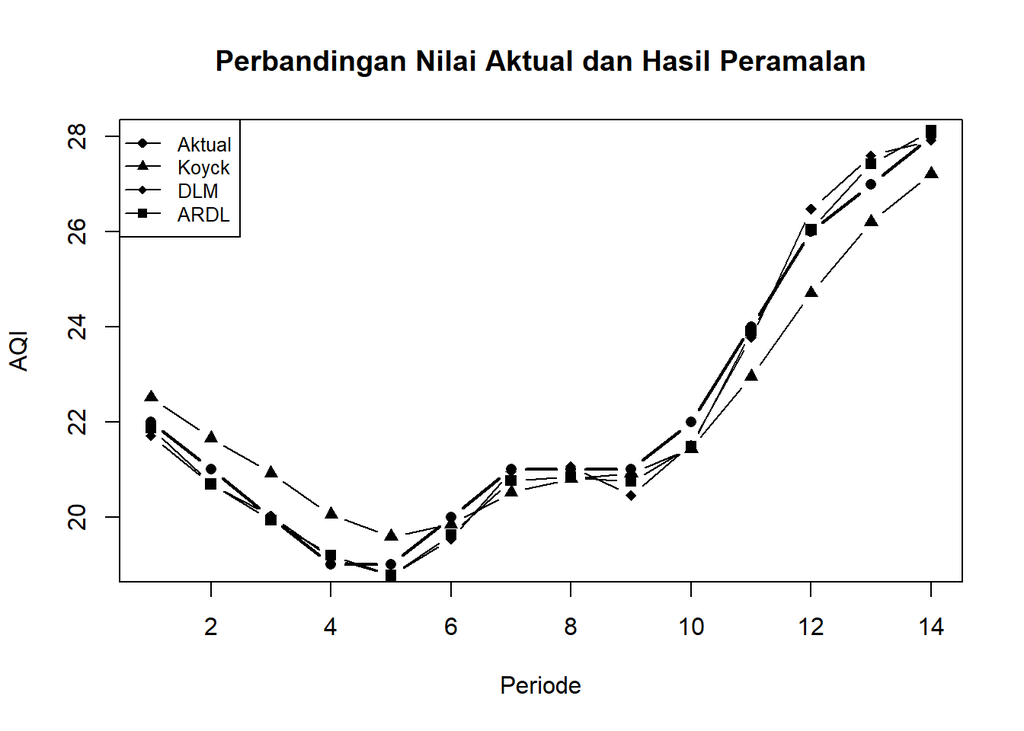

```r
plot(
  1:nrow(test),
  test$AQI,
  type = "b",
  pch = 16,
  lwd = 2,
  xlab = "Periode",
  ylab = "AQI",
  main = "Perbandingan Nilai Aktual dan Hasil Peramalan"
)

lines(
  1:nrow(test),
  fore.koyck$forecasts,
  type = "b",
  pch = 17
)

lines(
  1:nrow(test),
  fore.dlm.opt$forecasts,
  type = "b",
  pch = 18
)

lines(
  1:nrow(test),
  fore.ardl$forecasts,
  type = "b",
  pch = 15
)

legend(
  "topleft",
  legend = c("Aktual", "Koyck", "DLM", "ARDL"),
  lty = 1,
  pch = c(16, 17, 18, 15),
  cex = 0.8
)
```

**Interpretasi:** Berdasarkan grafik, hasil peramalan dari ketiga model dapat dibandingkan dengan nilai AQI aktual pada data testing. Secara umum, hasil peramalan ketiga model mengikuti pola perubahan nilai AQI aktual. Perbedaan ketepatan masing-masing model kemudian dapat dilihat lebih jelas melalui nilai MAPE.

Hasil MAPE menunjukkan bahwa model ARDL memiliki nilai kesalahan paling kecil, sehingga hasil peramalannya paling dekat dengan nilai aktual dibandingkan model Koyck dan DLM.

## 6.3 Ringkasan Perbandingan Model

```r
perbandingan <- data.frame(
  Model = c("Koyck", "DLM", "ARDL"),
  Spesifikasi = c(
    "Koyck",
    "DLM dengan q = 10",
    "ARDL dengan p = 1, q = 13"
  ),
  MAPE = c(
    mape.koyck * 100,
    mape.dlm.opt * 100,
    mape.ardl * 100
  )
)

perbandingan
```

```
##   Model               Spesifikasi     MAPE
## 1 Koyck                     Koyck 2.909543
## 2   DLM         DLM dengan q = 10 1.272540
## 3  ARDL ARDL dengan p = 1, q = 13 1.036365
```

**Interpretasi:** Berdasarkan hasil perbandingan, model ARDL(1,13) memiliki nilai MAPE paling kecil yaitu **1.04%**, diikuti oleh model DLM dengan $q=10$ sebesar **1.27%**, dan model Koyck sebesar **2.91%**. Dengan demikian, model ARDL(1,13) dipilih sebagai model dengan hasil peramalan terbaik pada data yang digunakan.

# 7. Kesimpulan

Berdasarkan analisis regresi dengan peubah lag pada data kualitas udara, AQI digunakan sebagai variabel dependen (Y) dan O3 sebagai variabel independen (X). Data terdiri dari 72 observasi yang dibagi menjadi 58 observasi untuk data training dan 14 observasi untuk data testing.

Tiga metode yang digunakan adalah model Koyck, DLM, dan ARDL. Pada model DLM, berdasarkan nilai AIC diperoleh lag optimum $q=10$. Sementara itu, pada model ARDL diperoleh dua kombinasi dengan nilai AIC terkecil yang sama, yaitu $p=1,q=13$ dan $p=1,q=14$. Model ARDL(1,13) digunakan karena memiliki jumlah lag yang lebih rendah.

Berdasarkan hasil evaluasi peramalan, model Koyck menghasilkan MAPE sebesar **2.91%**, model DLM dengan $q=10$ menghasilkan MAPE sebesar **1.27%**, dan model ARDL(1,13) menghasilkan MAPE sebesar **1.04%**. Karena memiliki nilai MAPE paling kecil, model **ARDL(1,13) dipilih sebagai model dengan hasil peramalan terbaik**.

Hasil uji asumsi pada model DLM dan ARDL menunjukkan bahwa seluruh *P-value* uji Durbin-Watson, Breusch-Pagan, dan Shapiro-Wilk lebih besar dari 0.05. Dengan demikian, tidak terdapat bukti yang cukup adanya autokorelasi positif dan heteroskedastisitas pada residual, serta asumsi normalitas residual dapat dianggap terpenuhi.

Secara keseluruhan, model ARDL(1,13) memberikan hasil peramalan AQI terbaik pada data testing yang digunakan dengan nilai MAPE sebesar **1.04%**.